# Практика · Постановка детекції

> Лекція: lecture.html · Тест: quiz.html · Домашнє завдання: homework.html

> 🔌 **Мережа не потрібна.** Усі дані зошит генерує формулами, ваги не завантажуються. Досить `torch`, `torchvision`, `numpy` і `matplotlib`.

> ⏱ Зошит навчає один детектор. Заміряно: **близько 70 секунд** на чотирьох ядрах без відеокарти. Найдовше йде саме навчання — 35-40 секунд.

Що зробимо:

1. напишемо **свій IoU** і звіримо з `torchvision.ops.box_iou`;
2. покажемо три різні помилки з однаковим IoU;
3. порахуємо, на скільки пікселів можна зсунути рамку при різних порогах;
4. згенеруємо сцени 64×64 й побачимо дисбаланс «предмет проти фону» в числах;
5. навчимо детектор і подивимось, скільки рамок він видає на 247 справжніх;
6. напишемо **свій NMS** і звіримо з `ops.nms` на тих самих входах;
7. напишемо **свій AP** і звіримо з ручним підрахунком на крихітному прикладі;
8. дістанемо `mAP@0.5` і `mAP@0.5:0.95` і побачимо різницю.

```python
import time
import numpy as np
import torch
import torch.nn as nn
from torchvision.ops import box_iou, nms, box_convert
import matplotlib.pyplot as plt

# один потік дає і швидкість на маленьких тензорах, і повторюваність чисел:
# під кількома потоками float-суми йдуть в іншому порядку
torch.set_num_threads(1)
torch.manual_seed(0)

print("torch      ", torch.__version__)
print("numpy      ", np.__version__)
print("потоків    ", torch.get_num_threads())
```

```
torch       2.10.0+cpu
numpy       2.5.1
потоків     1
```

## 1 · IoU власноруч

IoU — це площа перетину двох рамок, поділена на площу їхнього обʼєднання. Рамку скрізь записуємо у форматі `xyxy`: лівий-верхній кут і правий-нижній.

Перетин двох прямокутників — теж прямокутник. Його ліва межа — **правіша** з двох лівих меж, права — **лівіша** з двох правих. Якщо після цього ширина вийшла відʼємною, рамки просто не перетинаються, і площа дорівнює нулю.

```python
def iou_by_hand(box_a, box_b):
    """IoU двох рамок у форматі xyxy. Той самий розрахунок, що в бібліотеці."""
    inter_x1 = max(box_a[0], box_b[0])
    inter_y1 = max(box_a[1], box_b[1])
    inter_x2 = min(box_a[2], box_b[2])
    inter_y2 = min(box_a[3], box_b[3])

    # відʼємна сторона означає «не перетинаються», тому зрізаємо її нулем
    inter_w = max(0.0, inter_x2 - inter_x1)
    inter_h = max(0.0, inter_y2 - inter_y1)
    intersection = inter_w * inter_h

    area_a = (box_a[2] - box_a[0]) * (box_a[3] - box_a[1])
    area_b = (box_b[2] - box_b[0]) * (box_b[3] - box_b[1])
    # спільну частину при додаванні площ порахували двічі — віднімаємо один раз
    union = area_a + area_b - intersection

    return intersection / union if union > 0 else 0.0, intersection, union


first = [10.0, 10.0, 30.0, 30.0]
second = [20.0, 20.0, 40.0, 40.0]
value, intersection, union = iou_by_hand(first, second)

print("перетин    ", intersection)
print("обʼєднання ", union)
print("IoU руками  %.6f" % value)
```

```
перетин     100.0
обʼєднання  700.0
IoU руками  0.142857
```

Тепер те саме бібліотекою. `box_iou` приймає два тензори рамок і повертає матрицю «кожна з кожною», тому для двох рамок беремо єдину клітинку `[0, 0]`.

```python
library_value = box_iou(torch.tensor([first]), torch.tensor([second]))[0, 0].item()
print("IoU бібліотекою %.6f" % library_value)

assert abs(value - library_value) < 1e-6, "наш IoU розійшовся з box_iou!"
print("✅ збігається до шостого знака")
```

```
IoU бібліотекою 0.142857
✅ збігається до шостого знака
```

## 2 · Що IoU не розрізняє

Візьмімо квадрат 40×40 і три різні помилки, кожна з яких дає з ним IoU рівно 0.5:

- рамка **менша**: та сама середина, але сторона 40·√0.5 ≈ 28.3;
- рамка **зсунута**: та сама сторона 40, але зміщена на 40·(1−0.5)/(1+0.5) ≈ 13.3;
- рамка **навколо повернутого предмета**: сторона 40/√0.5 ≈ 56.6.

Формули беруться з рівняння «перетин ділити на обʼєднання дорівнює 0.5», розвʼязаного відносно сторони або зсуву. Перевіримо їх обчисленням.

```python
target_iou = 0.5
truth = [0.0, 0.0, 40.0, 40.0]

smaller_side = 40 * np.sqrt(target_iou)
offset = 40 * (1 - target_iou) / (1 + target_iou)
bigger_side = 40 / np.sqrt(target_iou)

variants = {
    "менша":     [(40 - smaller_side) / 2, (40 - smaller_side) / 2,
                  (40 + smaller_side) / 2, (40 + smaller_side) / 2],
    "зсунута":   [offset, 0.0, 40 + offset, 40.0],
    "повернута": [(40 - bigger_side) / 2, (40 - bigger_side) / 2,
                  (40 + bigger_side) / 2, (40 + bigger_side) / 2],
}

for name, box in variants.items():
    got, _, _ = iou_by_hand(truth, box)
    side = box[2] - box[0]
    print("%-10s сторона %5.1f  зсув %5.1f  IoU %.4f" %
          (name, side, box[0] - truth[0], got))
    assert abs(got - target_iou) < 1e-9, "варіант «%s» дав не 0.5" % name

print("✅ три різні помилки — одне й те саме число")
```

```
менша      сторона  28.3  зсув   5.9  IoU 0.5000
зсунута    сторона  40.0  зсув  13.3  IoU 0.5000
повернута  сторона  56.6  зсув  -8.3  IoU 0.5000
✅ три різні помилки — одне й те саме число
```

## 3 · На скільки можна промахнутись

Для двох рамок однакового розміру, зсунутих уздовж однієї осі на `s`, IoU дорівнює `(a − s) / (a + s)`, де `a` — сторона. Розвʼязавши це відносно `s`, дістаємо допустимий зсув для заданого порогу. Саме звідси беруться числа розділу 08 лекції.

```python
side_length = 40.0
print("рамка зі стороною %.0f px" % side_length)
print()
for wanted in (0.50, 0.75, 0.90):
    shift = side_length * (1 - wanted) / (1 + wanted)
    moved = [shift, 0.0, side_length + shift, side_length]
    check, _, _ = iou_by_hand([0.0, 0.0, side_length, side_length], moved)
    print("IoU %.2f → зсув %5.1f px (%.0f %% сторони), перевірка IoU = %.4f"
          % (wanted, shift, 100 * shift / side_length, check))
```

```
рамка зі стороною 40 px

IoU 0.50 → зсув  13.3 px (33 % сторони), перевірка IoU = 0.5000
IoU 0.75 → зсув   5.7 px (14 % сторони), перевірка IoU = 0.7500
IoU 0.90 → зсув   2.1 px (5 % сторони), перевірка IoU = 0.9000
```

## 4 · Формати рамки

Одна й та сама рамка записується трьома способами, і всі три — це просто чотири числа. Помилка при переплутуванні **тиха**: винятку не буде, буде поганий результат. `box_convert` перекладає між форматами.

```python
square = torch.tensor([[31.0, 40.0, 50.0, 59.0]])          # xyxy
as_xywh = box_convert(square, in_fmt="xyxy", out_fmt="xywh")
as_cxcywh = box_convert(square, in_fmt="xyxy", out_fmt="cxcywh")

print("xyxy   ", square.tolist()[0])
print("xywh   ", as_xywh.tolist()[0])
print("cxcywh ", as_cxcywh.tolist()[0])
print("нормовані (поділені на 64):",
      [round(v / 64, 3) for v in as_cxcywh.tolist()[0]])

# що буде, якщо xywh віддати функції, яка чекає xyxy
wrong = torch.tensor(as_xywh.tolist())
print()
print("IoU квадрата із самим собою, прочитаним як xyxy: %.4f"
      % box_iou(square, wrong)[0, 0].item())
print("Винятку немає — просто нуль. Саме так ця помилка й ховається.")
```

```
xyxy    [31.0, 40.0, 50.0, 59.0]
xywh    [31.0, 40.0, 19.0, 19.0]
cxcywh  [40.5, 49.5, 19.0, 19.0]
нормовані (поділені на 64): [0.633, 0.773, 0.297, 0.297]

IoU квадрата із самим собою, прочитаним як xyxy: 0.0000
Винятку немає — просто нуль. Саме так ця помилка й ховається.
```

## 5 · Датасет: сцени 64×64

Кожна сцена — полотно 64 на 64 пікселі, від одного до трьох предметів трьох класів (коло, квадрат, трикутник) радіусом 6-10 пікселів, шум зі стандартним відхиленням 0.12. Рамка кожного предмета рахується **з його маски**, тобто вона істинна за побудовою: людина її не ставила й помилитись не могла.

```python
SIZE, GRID, CELL = 64, 8, 8
CLASS_NAMES = ["коло", "квадрат", "трикутник"]


def shape_mask(kind, center_x, center_y, radius):
    """Маска однієї фігури на полотні 64×64."""
    ys, xs = np.mgrid[0:SIZE, 0:SIZE]
    if kind == 0:                                   # коло
        return (xs - center_x) ** 2 + (ys - center_y) ** 2 <= radius * radius
    if kind == 1:                                   # квадрат
        return (np.abs(xs - center_x) <= radius) & (np.abs(ys - center_y) <= radius)
    # трикутник: ширина росте згори вниз
    return ((ys - center_y + radius >= 0) & (ys - center_y <= radius)
            & (np.abs(xs - center_x) <= (ys - center_y + radius) / 2.0))


def make_scene(rng):
    """Одна сцена: картинка, рамки з масок, мітки класів."""
    image = np.zeros((SIZE, SIZE), np.float32)
    boxes, labels = [], []
    for _ in range(int(rng.integers(1, 4))):
        for _attempt in range(40):
            radius = int(rng.integers(6, 11))
            center_x = int(rng.integers(radius + 1, SIZE - radius - 1))
            center_y = int(rng.integers(radius + 1, SIZE - radius - 1))
            kind = int(rng.integers(0, 3))
            mask = shape_mask(kind, center_x, center_y, radius)
            ys, xs = np.nonzero(mask)
            # рамка беруться з маски: край + 1, як в угоді COCO
            box = [float(xs.min()), float(ys.min()),
                   float(xs.max() + 1), float(ys.max() + 1)]

            # не даємо предметам злипатись більше ніж на 45 % площі нового
            too_close = False
            for previous in boxes:
                overlap_w = max(0, min(box[2], previous[2]) - max(box[0], previous[0]))
                overlap_h = max(0, min(box[3], previous[3]) - max(box[1], previous[1]))
                if overlap_w * overlap_h > 0.45 * (box[2] - box[0]) * (box[3] - box[1]):
                    too_close = True
                    break
            if too_close:
                continue

            image[mask] = 1.0
            boxes.append(box)
            labels.append(kind)
            break
    image = np.clip(image + rng.normal(0, 0.12, (SIZE, SIZE)).astype(np.float32), 0, 1)
    return image, np.array(boxes, np.float32), np.array(labels, np.int64)


def make_dataset(seed, count):
    rng = np.random.default_rng(seed)
    return [make_scene(rng) for _ in range(count)]


started = time.time()
train_set = make_dataset(42, 400)
test_set = make_dataset(7, 120)
true_box_count = sum(len(scene[1]) for scene in test_set)

print("згенеровано за %.2f с" % (time.time() - started))
print("навчальних сцен %d, перевірних %d" % (len(train_set), len(test_set)))
print("істинних рамок у перевірному наборі: %d" % true_box_count)
```

```
згенеровано за 0.17 с
навчальних сцен 400, перевірних 120
істинних рамок у перевірному наборі: 247
```

Подивимось на перші три перевірні сцени разом з їхніми істинними рамками.

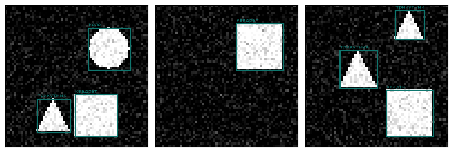

```
бірюзові прямокутники — еталонна розмітка, порахована з масок
```

```python
figure, axes = plt.subplots(1, 3, figsize=(9, 3.2))
for axis, (image, boxes, labels) in zip(axes, test_set[:3]):
    axis.imshow(image, cmap="gray", vmin=0, vmax=1)
    for box, label in zip(boxes, labels):
        axis.add_patch(plt.Rectangle((box[0], box[1]), box[2] - box[0], box[3] - box[1],
                                     fill=False, edgecolor="#0f766e", linewidth=1.6))
        axis.text(box[0], box[1] - 1, CLASS_NAMES[label], color="#0f766e", fontsize=7)
    axis.set_xticks([]); axis.set_yticks([])
plt.tight_layout()
plt.show()
print("бірюзові прямокутники — еталонна розмітка, порахована з масок")
```

## 6 · Дисбаланс у числах

Розібʼємо кожну сцену сіткою 8 на 8 і позначимо позитивною кожну клітинку, чий **центр** потрапив усередину якоїсь рамки. Ця сама розмітка стане ціллю для навчання. Заразом порахуємо, скільки клітинок припадає на фон.

```python
def encode_targets(boxes, labels):
    """Ціль детектора: обʼєктність, чотири числа рамки й клас на кожну клітинку."""
    objectness = np.zeros((GRID, GRID), np.float32)
    box_target = np.zeros((4, GRID, GRID), np.float32)
    class_target = np.zeros((GRID, GRID), np.int64)
    # якщо клітинка потрапила всередину двох рамок, вона відповідає за меншу
    smallest_area = np.full((GRID, GRID), 1e9, np.float32)

    for (x1, y1, x2, y2), label in zip(boxes, labels):
        box_area = (x2 - x1) * (y2 - y1)
        for row in range(GRID):
            for col in range(GRID):
                point_x = col * CELL + CELL / 2
                point_y = row * CELL + CELL / 2
                inside = (x1 <= point_x < x2) and (y1 <= point_y < y2)
                if not inside or box_area >= smallest_area[row, col]:
                    continue
                smallest_area[row, col] = box_area
                objectness[row, col] = 1.0
                # зсув центра рамки ВІД центра клітинки: так голова однакова
                # для всіх клітинок і не мусить знати своїх координат
                box_target[0, row, col] = ((x1 + x2) / 2 - point_x) / (4 * CELL) + 0.5
                box_target[1, row, col] = ((y1 + y2) / 2 - point_y) / (4 * CELL) + 0.5
                box_target[2, row, col] = (x2 - x1) / SIZE
                box_target[3, row, col] = (y2 - y1) / SIZE
                class_target[row, col] = label
    return objectness, box_target, class_target


def pack(dataset):
    images = np.stack([scene[0] for scene in dataset])[:, None]
    objectness, boxes, classes = [], [], []
    for _image, box_list, label_list in dataset:
        o, b, c = encode_targets(box_list, label_list)
        objectness.append(o); boxes.append(b); classes.append(c)
    return (torch.from_numpy(images), torch.from_numpy(np.stack(objectness)),
            torch.from_numpy(np.stack(boxes)), torch.from_numpy(np.stack(classes)))


train_images, train_obj, train_box, train_cls = pack(train_set)
test_images, _, _, _ = pack(test_set)

positive_cells = int(train_obj.sum().item())
all_cells = len(train_set) * GRID * GRID
objects_in_train = sum(len(scene[1]) for scene in train_set)

print("клітинок усього        %6d" % all_cells)
print("клітинок із предметом  %6d  (%.1f %%)" % (positive_cells,
                                                 100 * positive_cells / all_cells))
print("клітинок фону          %6d  (%.1f %%)" % (all_cells - positive_cells,
                                                 100 * (1 - positive_cells / all_cells)))
print()
print("предметів на сцену     %.2f" % (objects_in_train / len(train_set)))
print("клітинок на предмет    %.2f" % (positive_cells / objects_in_train))
print()
print("якби на предмет припадала рівно одна клітинка, фону було б %.1f %%"
      % (100 * 61 / 64))
print("Модель, яка мовчки каже «предмета немає», має саме цю «точність» — і нуль користі.")
```

```
клітинок усього         25600
клітинок із предметом    3732  (14.6 %)
клітинок фону           21868  (85.4 %)

предметів на сцену     2.06
клітинок на предмет    4.52

якби на предмет припадала рівно одна клітинка, фону було б 95.3 %
Модель, яка мовчки каже «предмета немає», має саме цю «точність» — і нуль користі.
```

## 7 · Детектор

Маленька згорткова мережа: три блоки «згортка + батчнорм + ReLU + пулінг» зменшують 64×64 до 8×8, а голова 1×1 віддає вісім чисел на клітинку — обʼєктність, чотири числа рамки й три класи.

```python
class Detector(nn.Module):
    def __init__(self):
        super().__init__()

        def block(in_channels, out_channels):
            return nn.Sequential(
                nn.Conv2d(in_channels, out_channels, 3, padding=1),
                nn.BatchNorm2d(out_channels), nn.ReLU(), nn.MaxPool2d(2))

        self.body = nn.Sequential(
            block(1, 16), block(16, 32), block(32, 64),
            nn.Conv2d(64, 64, 3, padding=1), nn.BatchNorm2d(64), nn.ReLU())
        self.head = nn.Conv2d(64, 8, 1)

    def forward(self, x):
        y = self.head(self.body(x))
        return y[:, 0], y[:, 1:5], y[:, 5:8]     # обʼєктність, рамка, класи


torch.manual_seed(0)
model = Detector()
print("параметрів:", sum(p.numel() for p in model.parameters()))
```

```
параметрів: 61096
```

Навчання: 25 епох, AdamW зі швидкістю навчання 3·10⁻³, партії по 32 сцени. Втрата складається з трьох доданків — обʼєктність по всіх клітинках, рамка й клас **лише по позитивних**.

⏱ Ця клітинка йде 35-40 секунд.

```python
optimizer = torch.optim.AdamW(model.parameters(), lr=3e-3)
objectness_loss = nn.BCEWithLogitsLoss()

started = time.time()
model.train()
for epoch in range(25):
    order = torch.randperm(len(train_images))
    for start in range(0, len(train_images), 32):
        batch = order[start:start + 32]
        images = train_images[batch]
        target_obj = train_obj[batch]
        target_box = train_box[batch]
        target_cls = train_cls[batch]

        predicted_obj, predicted_box, predicted_cls = model(images)
        loss = objectness_loss(predicted_obj, target_obj)

        positive = target_obj > 0.5
        # рамку й клас вимагаємо тільки там, де предмет справді є
        box_here = torch.sigmoid(predicted_box).permute(0, 2, 3, 1)[positive]
        loss = loss + 5.0 * ((box_here - target_box.permute(0, 2, 3, 1)[positive]) ** 2).mean()
        loss = loss + nn.functional.cross_entropy(
            predicted_cls.permute(0, 2, 3, 1)[positive], target_cls[positive])

        optimizer.zero_grad()
        loss.backward()
        optimizer.step()

training_seconds = time.time() - started
print("навчання зайняло %.1f с" % training_seconds)
print("остання втрата   %.4f" % loss.item())
```

```
навчання зайняло 36.5 с
остання втрата   0.0067
```

## 8 · Що видає детектор

Голова рахує рамку **з кожної клітинки**, тобто 64 рамки на сцену незалежно від того, скільки там предметів. Оцінкою рамки беремо добуток обʼєктності на ймовірність обраного класу — так роблять і справжні детектори.

```python
@torch.no_grad()
def predict(images):
    """Розкодовує вихід мережі в списки рамок, оцінок і класів — по сцені на список."""
    model.eval()
    raw_obj, raw_box, raw_cls = model(images)
    confidence = torch.sigmoid(raw_obj)
    box_values = torch.sigmoid(raw_box)
    class_probability = torch.softmax(raw_cls, 1)
    class_choice = raw_cls.argmax(1)

    results = []
    for n in range(len(images)):
        boxes, scores, labels = [], [], []
        for row in range(GRID):
            for col in range(GRID):
                point_x = col * CELL + CELL / 2
                point_y = row * CELL + CELL / 2
                center_x = point_x + (box_values[n, 0, row, col].item() - 0.5) * 4 * CELL
                center_y = point_y + (box_values[n, 1, row, col].item() - 0.5) * 4 * CELL
                width = box_values[n, 2, row, col].item() * SIZE
                height = box_values[n, 3, row, col].item() * SIZE
                label = int(class_choice[n, row, col].item())

                boxes.append([center_x - width / 2, center_y - height / 2,
                              center_x + width / 2, center_y + height / 2])
                scores.append(confidence[n, row, col].item()
                              * class_probability[n, label, row, col].item())
                labels.append(label)
        results.append((torch.tensor(boxes), torch.tensor(scores), torch.tensor(labels)))
    return results


raw_predictions = predict(test_images)
ground_truth = [(torch.from_numpy(scene[1]), torch.from_numpy(scene[2]))
                for scene in test_set]

CONFIDENCE = 0.05
above_threshold = sum(int((scores >= CONFIDENCE).sum())
                      for _boxes, scores, _labels in raw_predictions)

print("рамок узагалі         %5d  (120 сцен × 64 клітинки)" % (120 * 64))
print("рамок з оцінкою ≥ %.2f %5d" % (CONFIDENCE, above_threshold))
print("справжніх предметів   %5d" % true_box_count)
print()
print("Тобто на кожен предмет припадає близько %.1f рамки. Це не помилка навчання —"
      % (above_threshold / true_box_count))
print("це кілька клітинок, які бачать той самий предмет. Далі їх прибере NMS.")
```

```
рамок узагалі          7680  (120 сцен × 64 клітинки)
рамок з оцінкою ≥ 0.05  1134
справжніх предметів     247

Тобто на кожен предмет припадає близько 4.6 рамки. Це не помилка навчання —
це кілька клітинок, які бачать той самий предмет. Далі їх прибере NMS.
```

## 9 · Свій NMS проти бібліотечного

Алгоритм у чотири кроки: відсортувати за спаданням оцінки, узяти найвпевненішу, викинути все, що перекривається з нею сильніше за поріг, повторити.

Тонкість, у якій легко помилитись: викидаємо, коли IoU **строго більший** за поріг. Рамка з IoU рівно 0.5 при порозі 0.5 виживає — саме так поводиться `ops.nms`.

```python
def nms_by_hand(boxes, scores, threshold):
    """Повертає індекси рамок, які треба лишити."""
    order = torch.argsort(scores, descending=True).tolist()
    keep = []
    while order:
        best = order.pop(0)
        keep.append(best)
        survivors = []
        for candidate in order:
            overlap, _, _ = iou_by_hand(boxes[best].tolist(), boxes[candidate].tolist())
            if overlap <= threshold:          # строго більший — викидаємо
                survivors.append(candidate)
        order = survivors
    return keep


# звіряємо на справжніх передбаченнях: беремо кілька сцен і кілька порогів
mismatch = 0
for scene_index in range(12):
    boxes, scores, _labels = raw_predictions[scene_index]
    chosen = scores >= 0.02
    boxes, scores = boxes[chosen], scores[chosen]
    for threshold in (0.1, 0.3, 0.5, 0.7, 0.9):
        ours = nms_by_hand(boxes, scores, threshold)
        theirs = nms(boxes, scores, threshold).tolist()
        if ours != theirs:
            mismatch += 1
            print("розбіжність: сцена", scene_index, "поріг", threshold)

print("перевірено 12 сцен × 5 порогів, розбіжностей:", mismatch)
assert mismatch == 0, "наш NMS поводиться не так, як бібліотечний!"
print("✅ наш NMS дає ті самі індекси, що ops.nms")
```

```
перевірено 12 сцен × 5 порогів, розбіжностей: 0
✅ наш NMS дає ті самі індекси, що ops.nms
```

## 10 · Що NMS робить із реальними передбаченнями

Прогонимо весь перевірний набір при різних порогах NMS і подивимось, скільки рамок лишається. Заразом порахуємо точність і повноту — для цього потрібне зіставлення.

```python
def greedy_match(boxes, scores, truth_boxes, iou_threshold):
    """Жадібне зіставлення за спаданням упевненості.

    Повертає впорядковані оцінки й позначки «влучна / хибна» тієї самої довжини.
    Одну істинну рамку двічі не зараховуємо: інакше сто копій правильної рамки
    дали б сто влучань.
    """
    order = torch.argsort(scores, descending=True)
    taken = [False] * len(truth_boxes)
    hits = torch.zeros(len(order))

    if len(truth_boxes) and len(order):
        overlaps = box_iou(boxes[order], truth_boxes)
        for position in range(len(order)):
            best_value, best_index = -1.0, -1
            for truth_index in range(len(truth_boxes)):
                if taken[truth_index]:
                    continue
                if overlaps[position, truth_index].item() > best_value:
                    best_value = overlaps[position, truth_index].item()
                    best_index = truth_index
            if best_index >= 0 and best_value >= iou_threshold:
                taken[best_index] = True
                hits[position] = 1.0
    return scores[order], hits


def evaluate(confidence_threshold, nms_threshold, iou_threshold=0.5):
    """Точність і повнота всього набору при заданих трьох порогах."""
    all_scores, all_hits, box_count = [], [], 0
    for (boxes, scores, _labels), (truth_boxes, _truth_labels) in zip(raw_predictions,
                                                                     ground_truth):
        chosen = scores >= confidence_threshold
        boxes, scores = boxes[chosen], scores[chosen]
        if len(boxes):
            keep = nms(boxes, scores, nms_threshold)
            boxes, scores = boxes[keep], scores[keep]
        box_count += len(boxes)
        ordered_scores, hits = greedy_match(boxes, scores, truth_boxes, iou_threshold)
        all_scores.append(ordered_scores)
        all_hits.append(hits)

    scores = torch.cat(all_scores)
    hits = torch.cat(all_hits)
    precision = hits.sum().item() / max(1, len(hits))
    recall = hits.sum().item() / true_box_count
    return box_count, precision, recall, scores, hits


print("поріг NMS   рамок   точність   повнота")
for threshold in (0.1, 0.2, 0.3, 0.5, 0.7, 0.9):
    count, precision, recall, _, _ = evaluate(CONFIDENCE, threshold)
    print("   %.2f      %5d     %.3f      %.3f" % (threshold, count, precision, recall))

count, precision, recall, _, _ = evaluate(CONFIDENCE, 1.01)
print("  без NMS    %5d     %.3f      %.3f" % (count, precision, recall))
```

```
поріг NMS   рамок   точність   повнота
   0.10        220     0.973      0.866
   0.20        229     0.956      0.887
```

```
   0.30        244     0.939      0.927
```

```
   0.50        290     0.828      0.972
```

```
   0.70        485     0.501      0.984
   0.90       1024     0.238      0.988
  без NMS     1134     0.215      0.988
```

Головне тут — не окремі числа, а їхній обмін. Жадібний поріг 0.1 піднімає точність майже до одиниці, але викидає разом із дублікатами й справжні предмети: повнота падає. Відсутність NMS зберігає повноту, але точність стає непристойною.

## 11 · Робоча точка й ручка порога

Тепер зафіксуємо NMS на 0.5 і покрутимо **поріг упевненості**. Ваги детектора при цьому не міняються — це буквально одна модель.

```python
NMS_THRESHOLD = 0.5
sweep = []
print("поріг      рамок   точність   повнота")
for threshold in (1e-4, 1e-3, 3e-3, 1e-2, 3e-2, 0.05, 0.1, 0.3, 0.5, 0.8, 0.95, 0.99, 0.999):
    count, precision, recall, _, _ = evaluate(threshold, NMS_THRESHOLD)
    sweep.append((threshold, count, precision, recall))
    print("%8.4f   %5d     %.3f      %.3f" % (threshold, count, precision, recall))

count, precision, recall, _, _ = evaluate(CONFIDENCE, NMS_THRESHOLD)
hits_count = round(precision * count)
print()
print("Робоча точка (поріг %.2f, NMS %.2f):" % (CONFIDENCE, NMS_THRESHOLD))
print("  %d рамок на %d істинних" % (count, true_box_count))
print("  влучних %d, хибних %d, пропущено %d"
      % (hits_count, count - hits_count, true_box_count - hits_count))
print("  точність %.3f, повнота %.3f" % (precision, recall))
```

```
поріг      рамок   точність   повнота
```

```
  0.0001    5769     0.042      0.988
```

```
  0.0010    2213     0.109      0.980
  0.0030     529     0.457      0.980
```

```
  0.0100     335     0.722      0.980
```

```
  0.0300     297     0.811      0.976
```

```
  0.0500     290     0.828      0.972
  0.1000     285     0.842      0.972
```

```
  0.3000     280     0.857      0.972
```

```
  0.5000     278     0.863      0.972
  0.8000     274     0.876      0.972
  0.9500     269     0.888      0.968
```

```
  0.9900     257     0.918      0.955
```

```
  0.9990     202     0.946      0.773

Робоча точка (поріг 0.05, NMS 0.50):
  290 рамок на 247 істинних
  влучних 240, хибних 50, пропущено 7
  точність 0.828, повнота 0.972
```

## 12 · AP: площа під кривою точність-повнота

Спершу перевіримо власну реалізацію на прикладі, який можна порахувати **на пальцях**. Три істинні предмети, пʼять передбачень; перше влучне, друге хибне, третє влучне, четверте хибне, пʼяте влучне.

Крива йде так:

| крок | влучних | усього | точність | повнота |
| --- | --- | --- | --- | --- |
| 1 | 1 | 1 | 1.000 | 0.333 |
| 2 | 1 | 2 | 0.500 | 0.333 |
| 3 | 2 | 3 | 0.667 | 0.667 |
| 4 | 2 | 4 | 0.500 | 0.667 |
| 5 | 3 | 5 | 0.600 | 1.000 |

Огинальна (найбільша точність праворуч) у трьох точках, де повнота росте, дорівнює 1.000, 0.667 і 0.600. Площа береться прирістом повноти на цю точність:

`AP = 1/3 · 1.000 + 1/3 · 0.667 + 1/3 · 0.600 = 0.7556`

```python
def average_precision(scores, hits, truth_count, method="all"):
    """AP за оцінками й позначками влучності. Два способи взяти площу."""
    order = torch.argsort(scores, descending=True)
    ordered_hits = hits[order]

    running_hits = torch.cumsum(ordered_hits, 0)
    running_misses = torch.cumsum(1 - ordered_hits, 0)
    precision = running_hits / (running_hits + running_misses)
    recall = running_hits / truth_count

    if method == "eleven":
        total = 0.0
        for level in np.arange(0, 1.001, 0.1):
            reachable = recall >= level - 1e-9
            total += precision[reachable].max().item() if reachable.any() else 0.0
        return total / 11.0

    # огинальна: у кожній точці беремо найбільшу точність, досяжну праворуч
    envelope = precision.clone()
    for i in range(len(envelope) - 2, -1, -1):
        envelope[i] = max(envelope[i].item(), envelope[i + 1].item())

    area, previous_recall = 0.0, 0.0
    for i in range(len(envelope)):
        area += (recall[i].item() - previous_recall) * envelope[i].item()
        previous_recall = recall[i].item()
    return area


tiny_scores = torch.tensor([0.9, 0.8, 0.7, 0.6, 0.5])
tiny_hits = torch.tensor([1.0, 0.0, 1.0, 0.0, 1.0])
our_value = average_precision(tiny_scores, tiny_hits, 3, "all")
by_hand = (1 / 3) * 1.0 + (1 / 3) * (2 / 3) + (1 / 3) * 0.6

print("наша функція  %.6f" % our_value)
print("руками        %.6f" % by_hand)
# порівнюємо з допуском: тензори float32 не дають точних третин
assert abs(our_value - by_hand) < 1e-6, "AP розійшовся з ручним підрахунком!"
print("✅ збігається")
```

```
наша функція  0.755556
руками        0.755556
✅ збігається
```

Тепер те саме на справжньому детекторі. Поріг упевненості беремо якнайнижчий — крива має пройти всі робочі точки, а не лише ту, яку ми обрали.

```python
_count, _precision, _recall, all_scores, all_hits = evaluate(1e-4, NMS_THRESHOLD, 0.5)

ap_all_points = average_precision(all_scores, all_hits, true_box_count, "all")
ap_eleven = average_precision(all_scores, all_hits, true_box_count, "eleven")

print("AP@0.5 методом усіх точок   %.4f" % ap_all_points)
print("AP@0.5 одинадцятиточковий   %.4f" % ap_eleven)
print("різниця                     %.4f" % (ap_all_points - ap_eleven))
print()
order = torch.argsort(all_scores, descending=True)
best_recall = (torch.cumsum(all_hits[order], 0) / true_box_count).max().item()
print("максимальна досяжна повнота %.4f" % best_recall)
print("Повноти 1.0 детектор не досягає ніколи, а одинадцятиточковий метод усе одно")
print("питає про неї й зараховує нуль. Один цей нуль важить 1/11 = %.4f." % (1 / 11))
```

```
AP@0.5 методом усіх точок   0.9314
AP@0.5 одинадцятиточковий   0.8663
різниця                     0.0651

максимальна досяжна повнота 0.9879
Повноти 1.0 детектор не досягає ніколи, а одинадцятиточковий метод усе одно
питає про неї й зараховує нуль. Один цей нуль важить 1/11 = 0.0909.
```

Намалюємо криву разом з її огинальною — саме під огинальною береться площа.

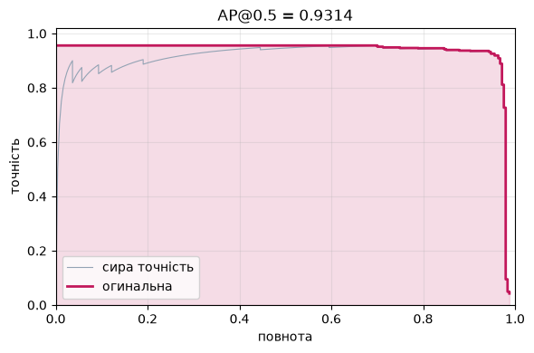

```
Площа під товстою лінією і є AP.
```

```python
order = torch.argsort(all_scores, descending=True)
ordered_hits = all_hits[order]
running_hits = torch.cumsum(ordered_hits, 0)
running_misses = torch.cumsum(1 - ordered_hits, 0)
precision_curve = (running_hits / (running_hits + running_misses)).numpy()
recall_curve = (running_hits / true_box_count).numpy()

envelope = precision_curve.copy()
for i in range(len(envelope) - 2, -1, -1):
    envelope[i] = max(envelope[i], envelope[i + 1])

plt.figure(figsize=(6, 4))
plt.plot(recall_curve, precision_curve, linewidth=0.8, color="#93a3b4", label="сира точність")
plt.plot(recall_curve, envelope, linewidth=2, color="#c2185b", label="огинальна")
plt.fill_between(recall_curve, envelope, alpha=0.15, color="#c2185b")
plt.xlabel("повнота"); plt.ylabel("точність")
plt.title("AP@0.5 = %.4f" % ap_all_points)
plt.xlim(0, 1); plt.ylim(0, 1.02); plt.legend(loc="lower left"); plt.grid(alpha=0.25)
plt.tight_layout(); plt.show()
print("Площа під товстою лінією і є AP.")
```

## 13 · mAP: усереднення по класах і по порогах IoU

`mAP@0.5` — середнє AP по класах при одному порозі. `mAP@0.5:0.95` — середнє по десяти порогах від 0.50 до 0.95 із кроком 0.05. Це один і той самий детектор, і різниця між двома числами показує, наскільки точно він ставить рамку.

```python
def average_precision_for_class(class_index, iou_threshold):
    """AP одного класу: його рамки проти його ж істинних рамок."""
    scores_parts, hits_parts, truth_count = [], [], 0
    for (boxes, scores, labels), (truth_boxes, truth_labels) in zip(raw_predictions,
                                                                    ground_truth):
        chosen = (scores >= 1e-4) & (labels == class_index)
        picked_boxes, picked_scores = boxes[chosen], scores[chosen]
        if len(picked_boxes):
            keep = nms(picked_boxes, picked_scores, NMS_THRESHOLD)
            picked_boxes, picked_scores = picked_boxes[keep], picked_scores[keep]

        this_class_truth = truth_boxes[truth_labels == class_index]
        truth_count += len(this_class_truth)
        ordered_scores, hits = greedy_match(picked_boxes, picked_scores,
                                            this_class_truth, iou_threshold)
        scores_parts.append(ordered_scores)
        hits_parts.append(hits)

    return average_precision(torch.cat(scores_parts), torch.cat(hits_parts),
                             max(1, truth_count), "all"), truth_count


thresholds = [round(float(t), 2) for t in np.arange(0.5, 0.951, 0.05)]
grid = []
print("клас        рамок   AP@0.5   AP@0.5:0.95")
for class_index in range(3):
    row = [average_precision_for_class(class_index, t)[0] for t in thresholds]
    grid.append(row)
    _value, count = average_precision_for_class(class_index, 0.5)
    print("%-11s %5d   %.4f   %.4f" % (CLASS_NAMES[class_index], count,
                                        row[0], float(np.mean(row))))

map_50 = float(np.mean([row[0] for row in grid]))
map_50_95 = float(np.mean([np.mean(row) for row in grid]))
print()
print("mAP@0.5      = %.4f" % map_50)
print("mAP@0.5:0.95 = %.4f" % map_50_95)
print()
print("Це одна модель на тих самих 120 сценах. Від першого числа до другого")
print("зникло %.1f %% — саме стільки коштує вимога ставити рамку точно."
      % (100 * (map_50 - map_50_95) / map_50))
```

```
клас        рамок   AP@0.5   AP@0.5:0.95
```

```
коло           84   0.9216   0.4459
```

```
квадрат        76   0.9620   0.5540
```

```
трикутник      87   0.9342   0.4700

mAP@0.5      = 0.9393
mAP@0.5:0.95 = 0.4900

Це одна модель на тих самих 120 сценах. Від першого числа до другого
зникло 47.8 % — саме стільки коштує вимога ставити рамку точно.
```

Подивимось, як AP спадає з ростом порога IoU. Наш детектор передбачає рамку з клітинки 8×8 пікселів, тому 2-3 пікселі похибки для нього норма — і при порозі 0.9 від AP не лишається майже нічого.

```
поріг IoU   коло    квадрат  трикутник  середнє
   0.50     0.9216  0.9620   0.9342     0.9393
   0.55     0.9195  0.9277   0.9067     0.9180
   0.60     0.8790  0.9151   0.8470     0.8804
   0.65     0.7609  0.8973   0.8080     0.8221
   0.70     0.4750  0.7290   0.6046     0.6029
   0.75     0.3236  0.5497   0.4554     0.4429
   0.80     0.1623  0.4028   0.1263     0.2305
   0.85     0.0159  0.1410   0.0178     0.0583
   0.90     0.0014  0.0147   0.0000     0.0054
   0.95     0.0000  0.0009   0.0000     0.0003
```

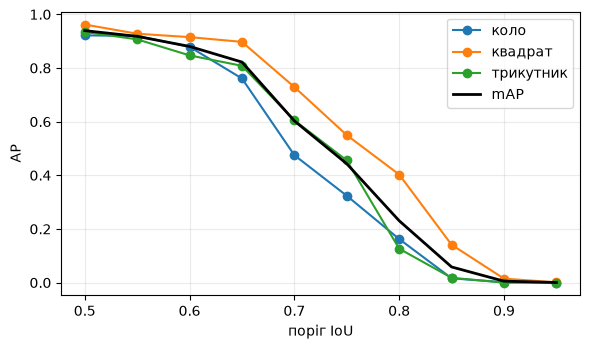

```
Чим суворіший поріг, тим менше лишається від тієї самої моделі.
```

```python
print("поріг IoU   коло    квадрат  трикутник  середнє")
for column, threshold in enumerate(thresholds):
    values = [grid[c][column] for c in range(3)]
    print("   %.2f     %.4f  %.4f   %.4f     %.4f"
          % (threshold, values[0], values[1], values[2], float(np.mean(values))))

plt.figure(figsize=(6, 3.6))
for class_index in range(3):
    plt.plot(thresholds, grid[class_index], marker="o", label=CLASS_NAMES[class_index])
plt.plot(thresholds, [float(np.mean([grid[c][i] for c in range(3)]))
                      for i in range(len(thresholds))],
         color="black", linewidth=2, label="mAP")
plt.xlabel("поріг IoU"); plt.ylabel("AP"); plt.grid(alpha=0.25); plt.legend()
plt.tight_layout(); plt.show()
print("Чим суворіший поріг, тим менше лишається від тієї самої моделі.")
```

## 14 · Де NMS ламається

Досі NMS виглядав корисним. Ось випадок, у якому він робить непоправну шкоду: два **різні справжні** предмети, що перекриваються, — машина за машиною, людина за людиною. Рамки 60 на 120 пікселів, задня зсунута вбік на кілька пікселів.

```python
print("зсув     IoU     поріг 0.3    поріг 0.5    поріг 0.7")
for shift in (10, 15, 20, 25):
    pair = torch.tensor([[0.0, 0.0, 60.0, 120.0],
                         [float(shift), 0.0, 60.0 + shift, 120.0]])
    confidences = torch.tensor([0.90, 0.85])
    overlap = box_iou(pair[:1], pair[1:])[0, 0].item()

    verdicts = []
    for threshold in (0.3, 0.5, 0.7):
        survivors = len(nms(pair, confidences, threshold))
        verdicts.append("обидві   " if survivors == 2 else "ЗАГУБИЛИ ")
    print("%2d px   %.3f    %s    %s    %s" % (shift, overlap, *verdicts))

print()
print("При загальноприйнятому порозі 0.5 два предмети, що стоять на відстані")
print("10 або 15 пікселів, перетворюються на один: NMS викидає задній назавжди.")
print("Жоден наступний етап його не поверне — у метриці це буде звичайний пропуск.")
```

```
зсув     IoU     поріг 0.3    поріг 0.5    поріг 0.7
10 px   0.714    ЗАГУБИЛИ     ЗАГУБИЛИ     ЗАГУБИЛИ
```

```
15 px   0.600    ЗАГУБИЛИ     ЗАГУБИЛИ     обидві
20 px   0.500    ЗАГУБИЛИ     обидві       обидві
25 px   0.412    ЗАГУБИЛИ     обидві       обидві

При загальноприйнятому порозі 0.5 два предмети, що стоять на відстані
10 або 15 пікселів, перетворюються на один: NMS викидає задній назавжди.
Жоден наступний етап його не поверне — у метриці це буде звичайний пропуск.
```

Підняти поріг теж не вихід: ми вже бачили в розділі 10, що при NMS 0.9 точність падає нижче за 0.25. Низький поріг губить справжні предмети, високий лишає дублікати, і геометрія не дає способу відрізнити одне від одного. Часткове лікування — **Soft-NMS**: перекритій рамці не викидають, а знижують упевненість тим сильніше, чим більший IoU. Радикальне — прибрати NMS зовсім, як це робить DETR, про який ітиметься в темі 27.

## 15 · Підсумок зошита

```python
print("Що поміряно:")
print()
print("  IoU руками                     %.6f  (box_iou: те саме)" % value)
print("  клітинок фону                  %.1f %%" % (100 * (1 - positive_cells / all_cells)))
print("  навчання детектора             %.1f с" % training_seconds)
print("  рамок до NMS                   %d на %d предметів" % (above_threshold,
                                                               true_box_count))
count, precision, recall, _, _ = evaluate(CONFIDENCE, NMS_THRESHOLD)
print("  рамок після NMS                %d, точність %.3f, повнота %.3f"
      % (count, precision, recall))
print("  AP@0.5 усі точки               %.4f" % ap_all_points)
print("  AP@0.5 одинадцять точок        %.4f" % ap_eleven)
print("  mAP@0.5                        %.4f" % map_50)
print("  mAP@0.5:0.95                   %.4f" % map_50_95)
print()
print("Головна пара чисел теми — два останні рядки. Це одна модель.")
```

```
Що поміряно:

  IoU руками                     0.142857  (box_iou: те саме)
  клітинок фону                  85.4 %
  навчання детектора             36.5 с
  рамок до NMS                   1134 на 247 предметів
  рамок після NMS                290, точність 0.828, повнота 0.972
  AP@0.5 усі точки               0.9314
  AP@0.5 одинадцять точок        0.8663
  mAP@0.5                        0.9393
  mAP@0.5:0.95                   0.4900

Головна пара чисел теми — два останні рядки. Це одна модель.
```

## Завдання

### 🟢 Рівень 1 — База

Зміни `CONFIDENCE` на 0.3 і 0.001 і перерахуй робочу точку. Побудуй графік «точність і повнота проти порога» за списком `sweep`.

**Зроблено, якщо:** графік показує, що зі зниженням порога повнота росте, а точність падає, і ти можеш назвати поріг, при якому точність уперше опускається нижче за 0.5.

### 🟡 Рівень 2 — Плюс

Порахуй AP окремо для **великих** і **малих** предметів: розділи істинні рамки за площею на дві половини й пропусти кожну групу через `average_precision`.

**Зроблено, якщо:** ти дістав два числа й можеш пояснити, чому вони різні — скориставшись таблицею допустимого зсуву з розділу 3.

### 🔴 Рівень 3 — Виклик

Реалізуй **Soft-NMS**: замість викидати перекриту рамку, помнож її оцінку на `exp(−IoU² / σ)` з `σ = 0.5`, а потім відкинь усе, що впало нижче за 0.05. Порівняй mAP@0.5 звичайного NMS і Soft-NMS на нашому перевірному наборі.

**Зроблено, якщо:** обидва числа надруковані, і ти можеш сказати, за рахунок чого змінилась різниця — точності чи повноти.